# Dimensionality Reduction

## Dimensionality Reduction

MNIST dataset which is a set of images of handwritten digits https://en.wikipedia.org/wiki/MNIST_database.

- Apply a Random Forest classification algorithm to MNIST dataset
- Perform dimensionality reduction of features using PCA and compare classification on the reduced dataset to that of original one
- Apply dimensionality reduction techniques: t-SNE and LLE

```python
import pandas as pd
import numpy as np
import matplotlib.pyplot as plt
import seaborn as sns
%matplotlib inline
```

```python
df=pd.read_csv('mnist_dataset.csv')
```

```python
df.head()
```

|  | Unnamed: 0 | label | 1x1 | 1x2 | 1x3 | 1x4 | 1x5 | 1x6 | 1x7 | 1x8 | ... | 28x19 | 28x20 | 28x21 | 28x22 | 28x23 | 28x24 | 28x25 | 28x26 | 28x27 | 28x28 |
| --- | --- | --- | --- | --- | --- | --- | --- | --- | --- | --- | --- | --- | --- | --- | --- | --- | --- | --- | --- | --- | --- |
| 0 | 0 | 2 | 0 | 0 | 0 | 0 | 0 | 0 | 0 | 0 | ... | 0 | 0 | 0 | 0 | 0 | 0 | 0 | 0 | 0 | 0 |
| 1 | 1 | 5 | 0 | 0 | 0 | 0 | 0 | 0 | 0 | 0 | ... | 0 | 0 | 0 | 0 | 0 | 0 | 0 | 0 | 0 | 0 |
| 2 | 2 | 8 | 0 | 0 | 0 | 0 | 0 | 0 | 0 | 0 | ... | 0 | 0 | 0 | 0 | 0 | 0 | 0 | 0 | 0 | 0 |
| 3 | 3 | 0 | 0 | 0 | 0 | 0 | 0 | 0 | 0 | 0 | ... | 0 | 0 | 0 | 0 | 0 | 0 | 0 | 0 | 0 | 0 |
| 4 | 4 | 4 | 0 | 0 | 0 | 0 | 0 | 0 | 0 | 0 | ... | 0 | 0 | 0 | 0 | 0 | 0 | 0 | 0 | 0 | 0 |

5 rows × 786 columns

```python
df.describe()
#Unnamed column is just an ID column therefore is no necessary for our algorythm
```

|  | Unnamed: 0 | label | 1x1 | 1x2 | 1x3 | 1x4 | 1x5 | 1x6 | 1x7 | 1x8 | ... | 28x19 | 28x20 | 28x21 | 28x22 | 28x23 | 28x24 | 28x25 | 28x26 | 28x27 | 28x28 |
| --- | --- | --- | --- | --- | --- | --- | --- | --- | --- | --- | --- | --- | --- | --- | --- | --- | --- | --- | --- | --- | --- |
| count | 70000.000000 | 70000.000000 | 70000.0 | 70000.0 | 70000.0 | 70000.0 | 70000.0 | 70000.0 | 70000.0 | 70000.0 | ... | 70000.000000 | 70000.000000 | 70000.000000 | 70000.000000 | 70000.000000 | 70000.000000 | 70000.0 | 70000.0 | 70000.0 | 70000.0 |
| mean | 34999.500000 | 4.452429 | 0.0 | 0.0 | 0.0 | 0.0 | 0.0 | 0.0 | 0.0 | 0.0 | ... | 0.197414 | 0.099543 | 0.046629 | 0.016614 | 0.012957 | 0.001714 | 0.0 | 0.0 | 0.0 | 0.0 |
| std | 20207.403759 | 2.890195 | 0.0 | 0.0 | 0.0 | 0.0 | 0.0 | 0.0 | 0.0 | 0.0 | ... | 5.991206 | 4.256304 | 2.783732 | 1.561822 | 1.553796 | 0.320889 | 0.0 | 0.0 | 0.0 | 0.0 |
| min | 0.000000 | 0.000000 | 0.0 | 0.0 | 0.0 | 0.0 | 0.0 | 0.0 | 0.0 | 0.0 | ... | 0.000000 | 0.000000 | 0.000000 | 0.000000 | 0.000000 | 0.000000 | 0.0 | 0.0 | 0.0 | 0.0 |
| 25% | 17499.750000 | 2.000000 | 0.0 | 0.0 | 0.0 | 0.0 | 0.0 | 0.0 | 0.0 | 0.0 | ... | 0.000000 | 0.000000 | 0.000000 | 0.000000 | 0.000000 | 0.000000 | 0.0 | 0.0 | 0.0 | 0.0 |
| 50% | 34999.500000 | 4.000000 | 0.0 | 0.0 | 0.0 | 0.0 | 0.0 | 0.0 | 0.0 | 0.0 | ... | 0.000000 | 0.000000 | 0.000000 | 0.000000 | 0.000000 | 0.000000 | 0.0 | 0.0 | 0.0 | 0.0 |
| 75% | 52499.250000 | 7.000000 | 0.0 | 0.0 | 0.0 | 0.0 | 0.0 | 0.0 | 0.0 | 0.0 | ... | 0.000000 | 0.000000 | 0.000000 | 0.000000 | 0.000000 | 0.000000 | 0.0 | 0.0 | 0.0 | 0.0 |
| max | 69999.000000 | 9.000000 | 0.0 | 0.0 | 0.0 | 0.0 | 0.0 | 0.0 | 0.0 | 0.0 | ... | 254.000000 | 254.000000 | 253.000000 | 253.000000 | 254.000000 | 62.000000 | 0.0 | 0.0 | 0.0 | 0.0 |

8 rows × 786 columns

```python
df.keys()
```

```
Index(['Unnamed: 0', 'label', '1x1', '1x2', '1x3', '1x4', '1x5', '1x6', '1x7',
       '1x8',
       ...
       '28x19', '28x20', '28x21', '28x22', '28x23', '28x24', '28x25', '28x26',
       '28x27', '28x28'],
      dtype='object', length=786)
```

```python
df=df.drop('Unnamed: 0', axis=1)
```

```python
df.keys()
```

```
Index(['label', '1x1', '1x2', '1x3', '1x4', '1x5', '1x6', '1x7', '1x8', '1x9',
       ...
       '28x19', '28x20', '28x21', '28x22', '28x23', '28x24', '28x25', '28x26',
       '28x27', '28x28'],
      dtype='object', length=785)
```

```python
df.shape
```

```
(70000, 785)
```

```python
train=df.iloc[:60000]
test=df.iloc[60000:]
```

```python
print(f'There are {test.shape[0]} entries in the Test model.')
print(f'There are {train.shape[0]} entries in the Train model.')
```

```
There are 10000 entries in the Test model.
There are 60000 entries in the Train model.
```

Training a Random Forest Classifier, and evaluating its performance.

```python
X_test, y_test =  test.iloc[:,1:].values, test.iloc[:,0].values
X_train, y_train = train.iloc[:,1:].values, train.iloc[:,0].values
```

```python
import time
from sklearn.ensemble import RandomForestClassifier
```

```python
time_start=time.time()
clf = RandomForestClassifier(n_estimators = 100)
clf.fit(X_train, y_train)
print('Model complete! Time elapsed: {} seconds'.format(time.time()-time_start))
```

```
Model complete! Time elapsed: 39.46743869781494 seconds
```

```python
y_pred_test = clf.predict(X_test)
```

```python
from sklearn.metrics import accuracy_score, confusion_matrix, classification_report
```

```python
accuracy = accuracy_score(y_test,y_pred_test)
print(f'Accuracy of our Random Forest Classifier model is {(accuracy*100)}%')
```

```
Accuracy of our Random Forest Classifier model is 96.86%
```

Using PCA to reduce the dataset’s dimensionality, with an explained variance ratio of 95%. Training a new Random Forest classifier on the reduced dataset and see how long it takes.

```python
from sklearn.decomposition import PCA

pca = PCA(0.95).fit(X_train)
```

```python
pca_cum_var=np.cumsum(pca.explained_variance_ratio_)
dimension = np.argmax(pca_cum_var >=0.95) + 1
print(f'Number of dimensions needed to explain 95% variance ratio is {dimension}.')
```

```
Number of dimensions needed to explain 95% variance ratio is 154.
```

```python
pca = PCA(n_components=154, random_state = 123)
pca_t = pca.fit_transform(df)
pca_df=pd.DataFrame(pca_t)
```

```python
pca_t.shape
```

```
(70000, 154)
```

```python
train_pca=pca_df.iloc[:60000]
test_pca=pca_df.iloc[60000:]
```

```python
print(train_pca.shape)
print(test_pca.shape)
```

```
(60000, 154)
(10000, 154)
```

```python
X_train, y_train = train_pca.values, y_train
X_test, y_test = test_pca.values, y_test
```

```python
time_start=time.time()
clf = RandomForestClassifier(n_estimators = 100)
clf.fit(X_train, y_train)
print('Model complete! Time elapsed: {} seconds'.format(time.time()-time_start))
```

```
Model complete! Time elapsed: 81.33959436416626 seconds
```

The original model took **39** seconds to process, while the new model took **81** seconds. Second model took a lot longer to train.

```python
y_pred_test = clf.predict(X_test)
accuracy = accuracy_score(y_test,y_pred_test)
print(f'Accuracy of our Random Forest Classifier model is {(accuracy*100)}%')
```

```
Accuracy of our Random Forest Classifier model is 95.06%
```

The original model had accuracy of **96.86%** while the transformed data set has a slightly lower accuracy of **95.06%**.

Using t-SNE to reduce the MNIST dataset

```python
from sklearn.manifold import TSNE
```

```python
tsne = TSNE(n_components=2, verbose=1, perplexity=40, n_iter=300)

tsne_result = tsne.fit_transform(X_train)

print('t-SNE done! Time elapsed: {} seconds'.format(time.time()-time_start))
```

[output not shown]

[output cut: 12 more lines]

```
[t-SNE] Computed conditional probabilities for sample 50000 / 60000
[t-SNE] Computed conditional probabilities for sample 51000 / 60000
[t-SNE] Computed conditional probabilities for sample 52000 / 60000
[t-SNE] Computed conditional probabilities for sample 53000 / 60000
[t-SNE] Computed conditional probabilities for sample 54000 / 60000
[t-SNE] Computed conditional probabilities for sample 55000 / 60000
[t-SNE] Computed conditional probabilities for sample 56000 / 60000
[t-SNE] Computed conditional probabilities for sample 57000 / 60000
[t-SNE] Computed conditional probabilities for sample 58000 / 60000
[t-SNE] Computed conditional probabilities for sample 59000 / 60000
[t-SNE] Computed conditional probabilities for sample 60000 / 60000
[t-SNE] Mean sigma: 342.210484
[t-SNE] KL divergence after 250 iterations with early exaggeration: 98.239746
[t-SNE] KL divergence after 300 iterations: 5.031321
t-SNE done! Time elapsed: 238.30604887008667 seconds
```

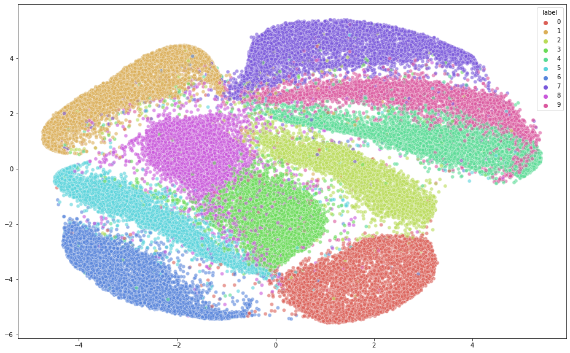

```python
tsne_df = pd.DataFrame(tsne_result)
tsne_df['label']=y_train
plt.figure(figsize=(16,10))
sns.scatterplot(x=tsne_result[:,0], y=tsne_result[:,1], hue='label',
               palette=sns.color_palette('hls', 10),
               data=tsne_df,
               alpha=0.6)
```

Comparing with other dimensionality methods: *Locally Linear Embedding* (LLE) or *Multidimensional scaling* (MDS).

```python
from sklearn.manifold import LocallyLinearEmbedding
lle = LocallyLinearEmbedding(n_components=2, n_neighbors=10, random_state=41, n_jobs=1)
X_reduced_cr=lle.fit_transform(X_train)
```

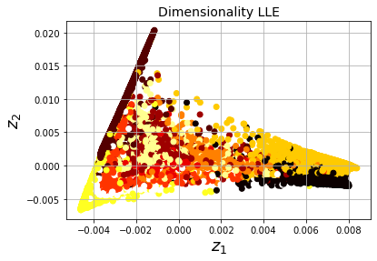

```python
plt.title("Dimensionality LLE", fontsize=14)
plt.scatter(X_reduced_cr[:, 0], X_reduced_cr[:, 1], c=y_train, cmap=plt.cm.hot)
plt.xlabel("$z_1$", fontsize=18)
plt.ylabel("$z_2$", fontsize=18)
plt.grid(True)
plt.show()
```